# Exploratory_analysis_and_visualization

Felix Tran

October 27, 2018

This file contains exploratory and visualization analyses done before any formal statistical testing.

# Loading the dataset

Loads the final dataset created from the data_cleaning file.

Get counts of usable, non-usable counties.

# Exposure data - Visualization

Looking at the distribution of gini coefficients across all counties

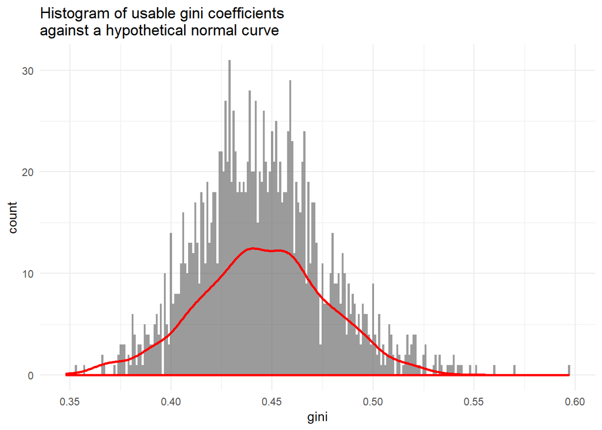

# Outcome data - Descriptive/summary statistics and visualizations

1 assumption of linear regression is that the residuals/error terms are normally distributed. This assumption would be violated if the distribution of age-adjusted suicide rates is not normally distributed. Therefore checking the distribution of the included outcome data is important.

### Summary and descriptive statistics

```
##    Min. 1st Qu.  Median    Mean 3rd Qu.    Max.    NA's
##    5.00   12.88   15.92   16.76   19.36   71.34    1458
```

```
## # A tibble: 1 x 2
##    mean    sd
##   <dbl> <dbl>
## 1  16.8  5.95
```

```
## # A tibble: 51 x 4
##    state                n_counties n_excluded prop_missing
##    <chr>                     <int>      <int>        <dbl>
##  1 Connecticut                   8          0        0
##  2 Delaware                      3          0        0
##  3 District of Columbia          1          0        0
##  4 New Hampshire                10          0        0
##  5 New Jersey                   21          0        0
##  6 Rhode Island                  5          0        0
##  7 Maine                        16          1        0.06
##  8 New York                     62          4        0.06
##  9 Arizona                      15          1        0.07
## 10 Maryland                     24          2        0.08
## 11 Pennsylvania                 67          7        0.1
## 12 California                   58          7        0.12
```

[output cut: 39 more lines]

### Plotting

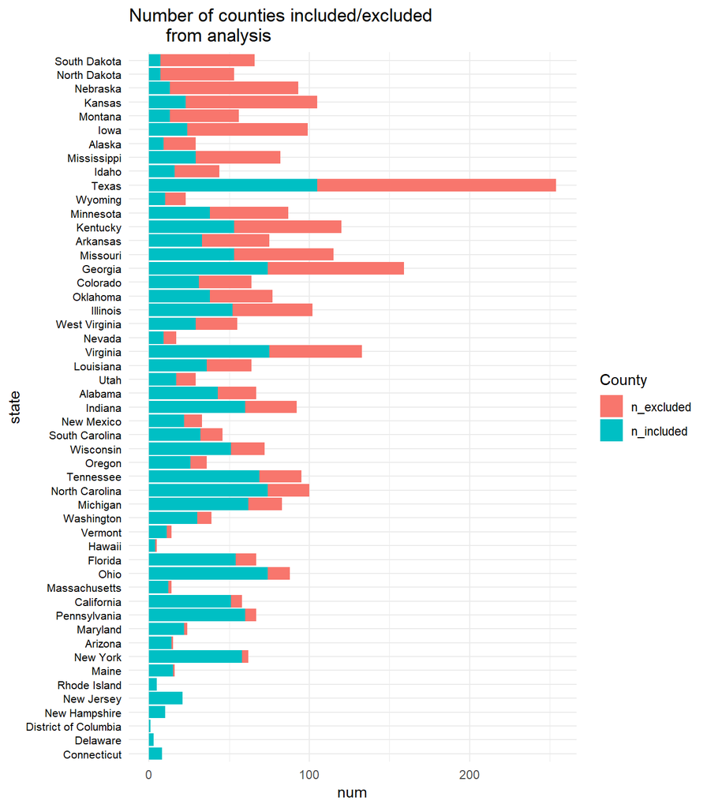

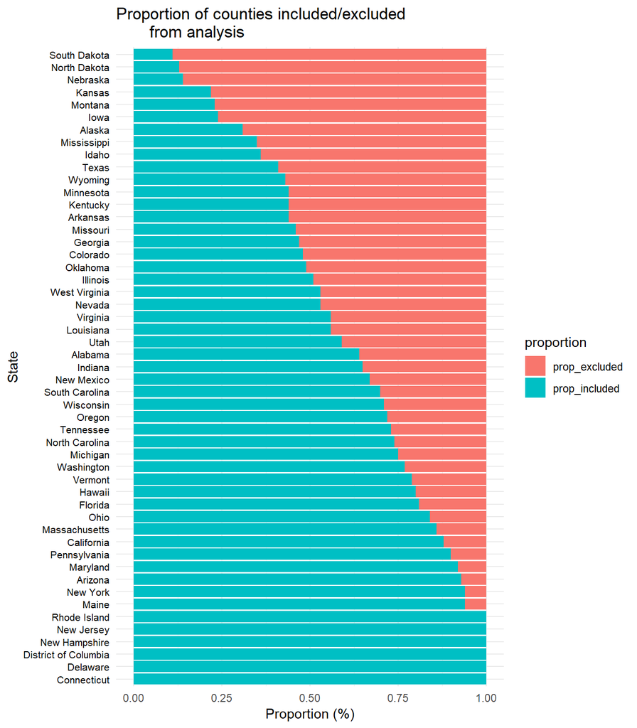

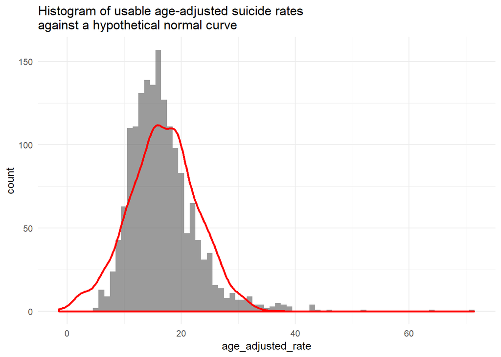

# Plotting covariates and outcome

Creating plots of covariates by outcome to see if any covariates should be transformed or recoded for the linear regression model

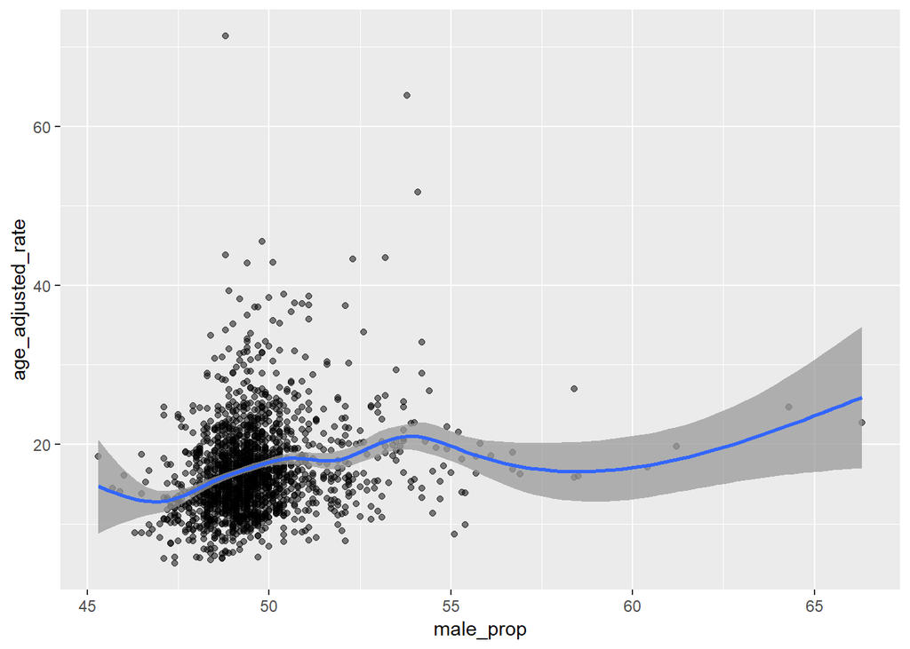

```r
final_df <- final_df %>%
  filter(usable == T) %>%
  select(gini, age_adjusted_rate, male_prop, white_prop, geriatric_prop,
         college_prop, poverty_prop, urban_rural_code)

# Sex
ggplot(data = final_df, aes(x = male_prop, y = age_adjusted_rate)) +
  geom_point(alpha = 0.5) +
  geom_smooth(alpha = 0.75)
```

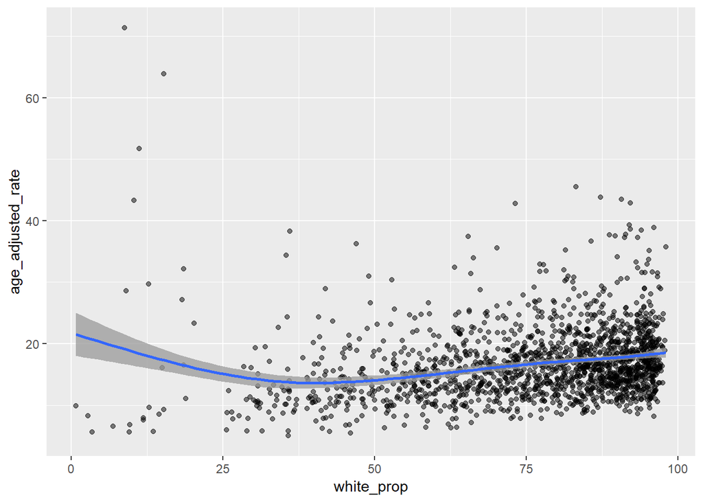

```r
# Race
ggplot(data = final_df, aes(x = white_prop, y = age_adjusted_rate)) +
  geom_point(alpha = 0.5) +
  geom_smooth(alpha = 0.75)
```

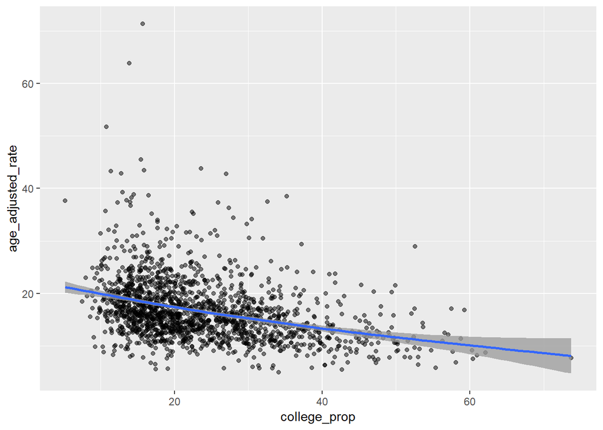

```r
# Education
ggplot(data = final_df, aes(x = college_prop, y = age_adjusted_rate)) +
  geom_point(alpha = 0.5) +
  geom_smooth(alpha = 0.75)
```

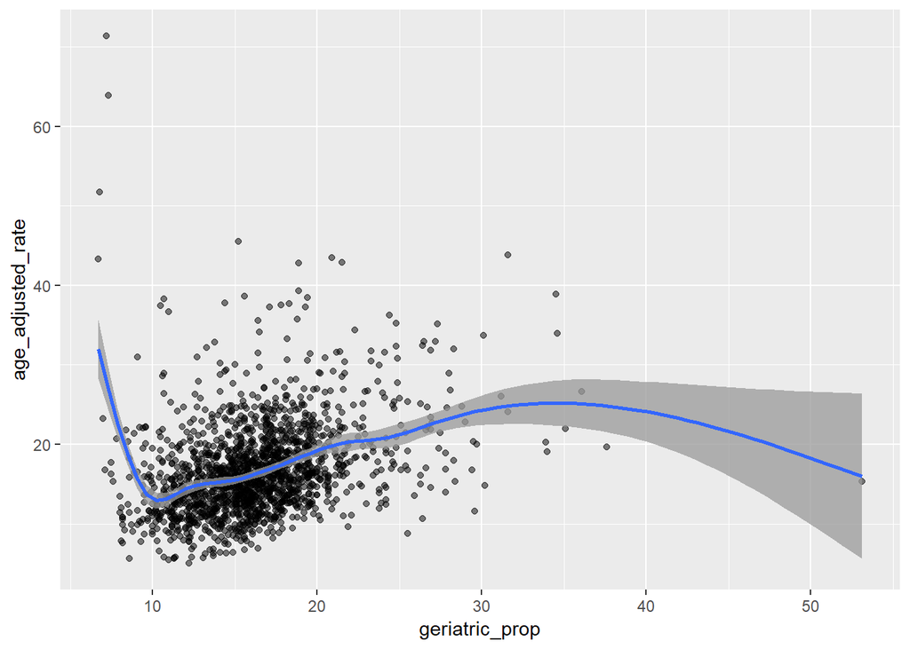

```r
# Age
ggplot(data = final_df, aes(x = geriatric_prop, y = age_adjusted_rate)) +
  geom_point(alpha = 0.5) +
  geom_smooth(alpha = 0.75)
```

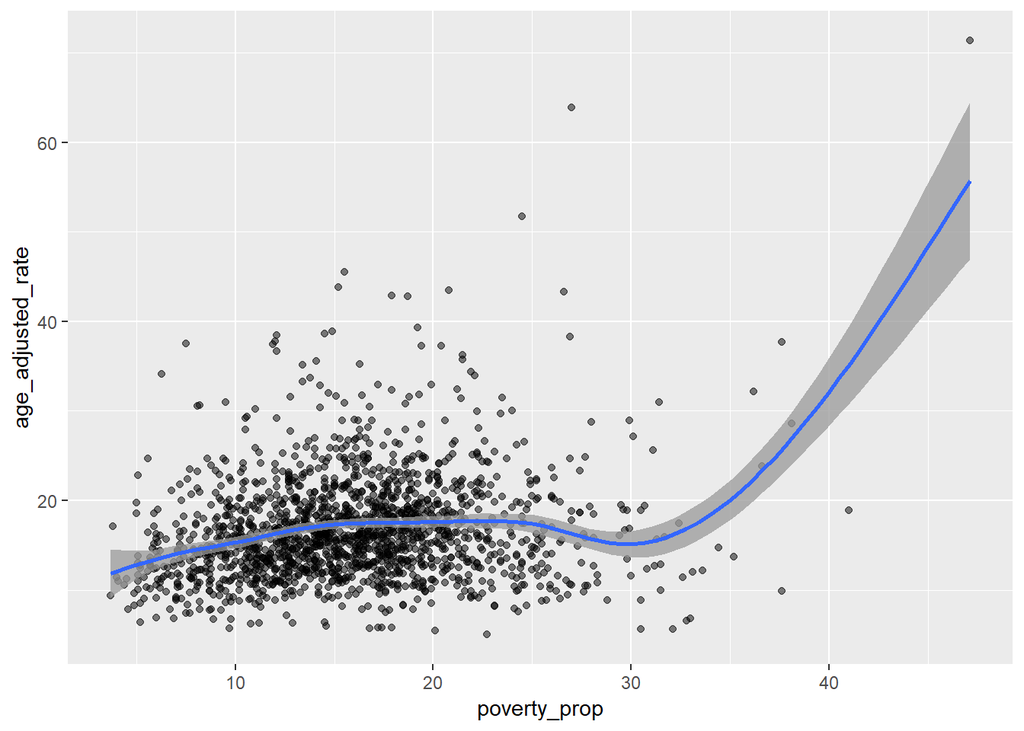

```r
# Poverty
ggplot(data = final_df, aes(x = poverty_prop, y = age_adjusted_rate)) +
  geom_point(alpha = 0.5) +
  geom_smooth(alpha = 0.75)
```

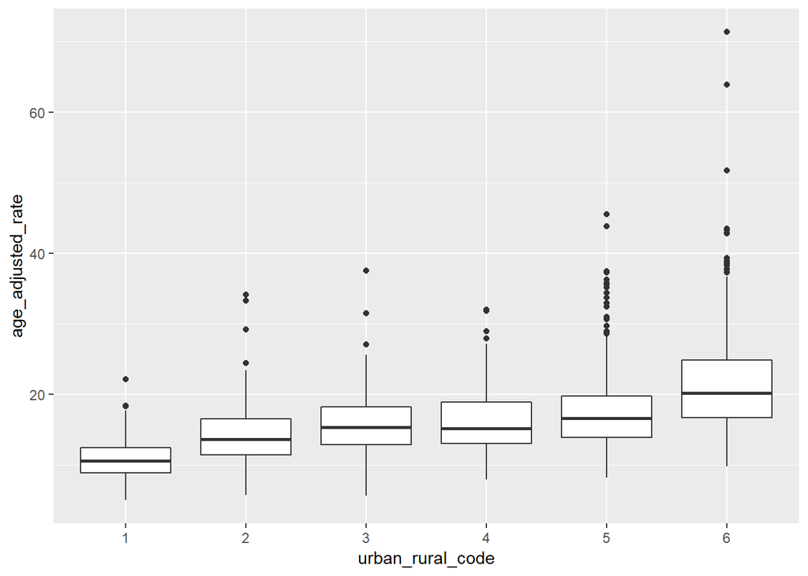

```r
# Urban-rural code
final_df %>%
  mutate(urban_rural_code = as.factor(urban_rural_code)) %>%
  ggplot(aes(x = urban_rural_code, y = age_adjusted_rate)) +
  geom_boxplot()
```

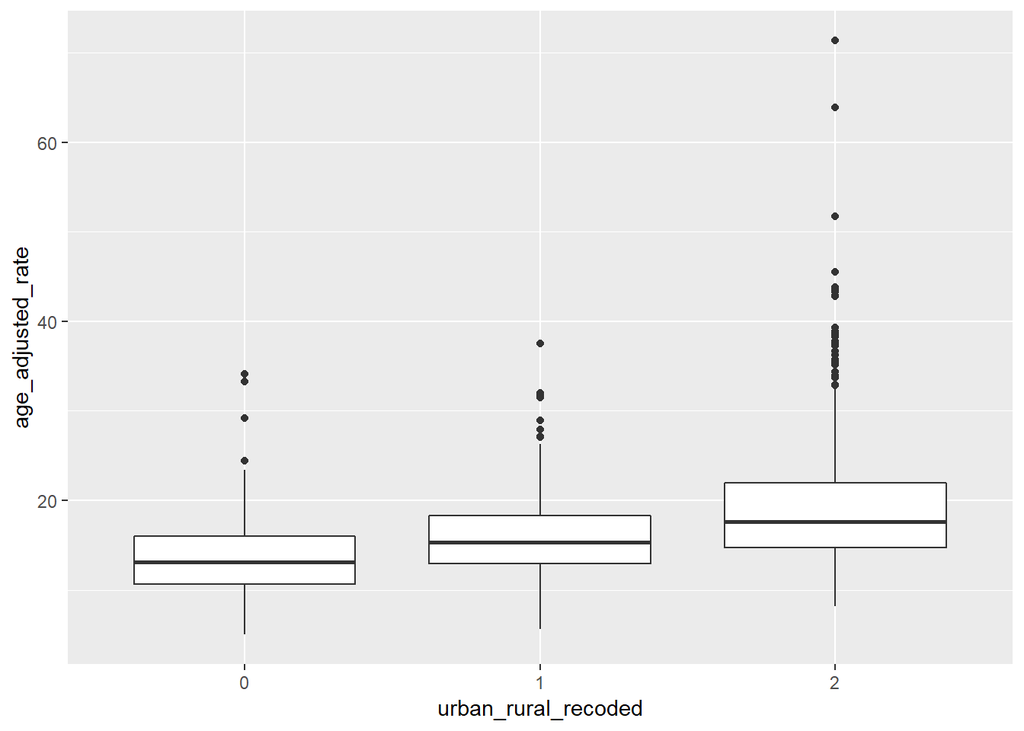

```r
# Urba-rural (collapsed into 3 categories)
final_df %>%
  mutate(urban_rural_recoded = as.integer((urban_rural_code - 1) / 2)) %>%
  mutate(urban_rural_recoded = as.factor(urban_rural_recoded)) %>%
  ggplot(aes(x = urban_rural_recoded, y = age_adjusted_rate)) +
  geom_boxplot()
```

The graphs of the crude relationships between each covariate and suicide rates are overall in line with my expectations. For all the covarites, there are a handful of outliers, but I feel the association as a whole won’t be changed by these outliers. Asides from collapsing urban_rural_code into 3 categories since 1 category has very few observations compared to the rest, I won’t transform the covariates.